# INFSCI 2595 Spring 2020: Weeks 6/7

Bayesian linear model

Dr. Joseph P. Yurko

## Overview

In week 06, we introduced linear models and mostly focused on understanding their behavior when the noise, $\sigma$, is known. We discussed how the MLE on $\sigma$ represents the mean squared error (MSE) of the model (based on the coefficient MLEs). Let’s now go through a Bayesian approach, which allows us to estimate the uncertainty on $\sigma$ as part of the fitting procedure. We will continue to use the Laplace Approximation as our tool for executing Bayesian inference. Since $\sigma$ has a natural lower bound, we will apply a transformation to $\sigma$ and so perform the Laplace Approximation on the transfored unbounded parameter, $\varphi$.

## Load libraries

This markdown requires the libraries loaded in the code chunk below. Functions from `purrr` and `MASS` are also used throughout the markdown.

```r
library(dplyr)
library(ggplot2)
```

## Create synthetic data

We will work with the synthetic data set discussed in lecture. The data are generated from an assumed true linear relationship between the mean trend and the single input $x$. The code chunk below specifies the true values for the intercept and slope to be $\beta_0 = -0.25$ and $\beta_1 = 1.15$, respectively. The true noise is set to be $\sigma = 0.5$. One hundred random input values are generated from a standard normal, the true mean trend is calculated for each input value, and then the response is generated around each mean, based on the assumed noise.

```r
### set the true linear predictor coefficients
beta_0_true <- -0.25
beta_1_true <- 1.15

sigma_true <- 0.5

### generate random input values
set.seed(4100)
x_demo <- rnorm(n = 100, mean = 0, sd = 1)

### evaluate the linear predictor and generate
### random, noisy observations
demo_df <- tibble::tibble(
  x = x_demo
) %>%
  mutate(mu = beta_0_true + beta_1_true * x,
         y = rnorm(n = n(), mean = mu, sd = sigma_true))
```

The random input values are visualized as a run style chart below, with the first 10 observations colored orange.

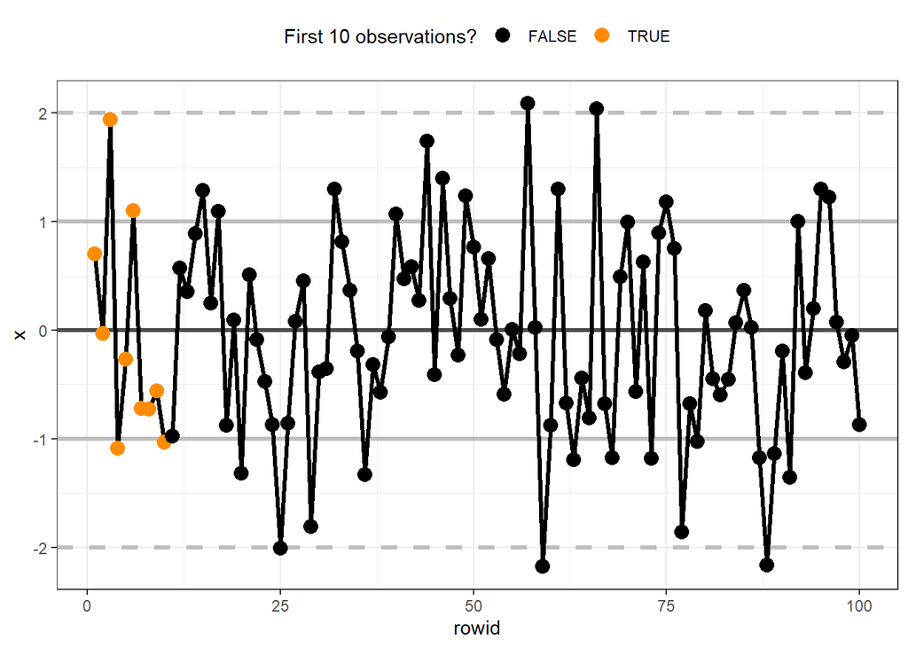

```r
demo_df %>%
  tibble::rowid_to_column() %>%
  ggplot(mapping = aes(x = rowid, y = x)) +
  geom_hline(yintercept = 0, color = "grey30", size = 1.15) +
  geom_hline(yintercept = c(-1, 1), color = "grey", size = 1.15) +
  geom_hline(yintercept = c(-2, 2), color = "grey", size = 1.15, linetype = "dashed") +
  geom_line(size = 1.15) +
  geom_point(mapping = aes(color = rowid < 11),
             size = 3.5) +
  scale_color_manual("First 10 observations?",
                     values = c("TRUE" = "darkorange",
                                "FALSE" = "black")) +
  theme_bw() +
  theme(legend.position = "top")
```

Let’s visualize the randomly generated responses associated with the random input values. For context, the true mean trend is shown as a black line and the true variation around the mean trend is represented by light blue ribbons. The ribbon “levels” correspond to the $\pm\sigma$, $\pm2\sigma$, and $\pm3\sigma$ intervals, respectively. The first ten random data points are displayed as large orange markers.

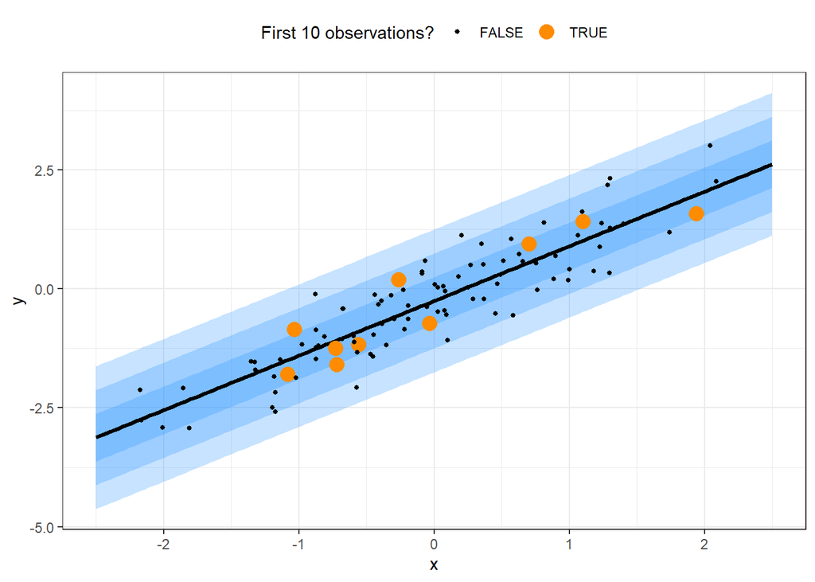

```r
### create the fine grid to aid the visualization
demo_fine <- tibble::tibble(
  x = seq(-2.5, 2.5, length.out = 101)
) %>%
  mutate(mu = beta_0_true + beta_1_true * x)

demo_fine %>%
  ggplot(mapping = aes(x = x)) +
  geom_ribbon(mapping = aes(ymin = mu - 3 * sigma_true,
                            ymax = mu + 3 * sigma_true,
                            group = 1),
              fill = "dodgerblue", alpha = 0.25) +
  geom_ribbon(mapping = aes(ymin = mu - 2 * sigma_true,
                            ymax = mu + 2 * sigma_true,
                            group = 1),
              fill = "dodgerblue", alpha = 0.25) +
  geom_ribbon(mapping = aes(ymin = mu - 1 * sigma_true,
                            ymax = mu + 1 * sigma_true,
                            group = 1),
              fill = "dodgerblue", alpha = 0.25) +
  geom_line(mapping = aes(y = mu,
                          group = 1),
            color = "black", size = 1.15) +
  geom_point(data = demo_df %>%
               tibble::rowid_to_column("obs_id"),
             mapping = aes(y = y,
                           color = obs_id < 11,
                           size = obs_id < 11)) +
  scale_color_manual("First 10 observations?",
                     values = c("TRUE" = "darkorange",
                                "FALSE" = "black")) +
  scale_size_manual("First 10 observations?",
                    values = c("TRUE" = 4,
                               "FALSE" = 1.15)) +
  labs(x = "x", y = "y") +
  theme_bw() +
  theme(axis.title = element_text(size = 11),
        legend.position = "top")
```

Let’s slice our complete datta set into the first ten random observations as the training set, and leave out the remaining 90 observations as a hold-out test set. This is usually not the best idea for splitting a data set. Preferably you would want to use a random split. However, since we literally generated the data ourselves and we know the ordering does not matter, it’s safe to do and helps with the illustration of which specific data points we are using.

```r
train_df <- demo_df %>%
  tibble::rowid_to_column("obs_id") %>%
  filter(obs_id < 11)

test_df <- demo_df %>%
  tibble::rowid_to_column("obs_id") %>%
  filter(obs_id > 10)
```

## Log-posterior function

### Original variables

We will use a linear relationship between the mean trend and the single input. We know that this is the actual data generating process which created the random observations. So we should anticipate our model fitting the data quite well, and generalizing the test set. Compared with most of the lecture from Week 06, we will treat the noise, $\sigma$, as uncertain. Our learning objective is therefore to learn the unknown intercept, $\beta_0$, the unknown slope, $\beta_1$, and the unknown noise, $\sigma$, based on the first 10 random observations, $\mathbf{y}$, and their associated input values, $\mathbf{x}$.

The joint posterior on all unknown quantities, given the observations, is written in general terms below. The likelihood has already been factored into the product $N$ separate likelihoods for each observation, due to conditional independence.

$$p\left(\beta_0, \beta_1, \sigma \mid \mathbf{y}, \mathbf{x} \right) \propto \prod_{n=1}^{N} \left( p\left(y_n \mid x_n, \beta_0, \beta_1, \sigma \right) \right) \times p\left(\beta_0\right) p\left(\beta_1\right) \times p\left(\sigma\right)$$

The complete probability model, which shows the $n$-th observation’s likelihood, the deterministic mean trend, and the prior on the parameters is shown below.

$$y_n \mid \mu_n, \sigma \sim \mathrm{normal}\left(y_n \mid \mu_n, \sigma\right) \\ \mu_n = \beta_0 + \beta_1 x_n \\ \beta_0 \sim \mathrm{normal} \left(\beta_0 \mid 0, 2.5 \right) \\ \beta_1 \sim \mathrm{normal} \left(\beta_1 \mid 0, 2.5 \right) \\ \sigma \sim \mathrm{Uniform}\left( \sigma \mid l = 0.05, u = 5 \right)$$

The complete probability model is encoded into the `my_logpost_lm_a()` function within the code chunk below. The format is the same that used in lecture and the homework assignments. The first input argument, `unknowns`, is a vector of all unknown variables. The second argument, `my_info`, is a list which contains all other information necessary for the function. The unknown parameters are ordered as shown in the first few lines of the functions. The intercept is the first element of `unknowns`, the slope is the second, and the noise is the third element. With a single input linearly related to the mean trend, we have 2 total model coefficients or $\beta$ parameters. Since the noise is also unknown the complete model therefore has a total of 3 unknown parameters!

The difference between the `my_logplost_lm_a()` and those previously used in this course, is that now a mean trend must be calculated. The observed input values are stored in the `$xobs` field in `my_info`, and the observed responses are stored as the `$yobs` field. Thus, before we can evaluate the log-likelihood, we need to use the $\beta$ parameters and the input values to calculate the mean trend. The log-likelihood then relates the observed responses to the mean trend.

As stated previously, the intercept and slope are given independent normal priors. Since we are using the same prior mean and prior standard deviation for both the `my_info` list contains fields `$mu_beta` and `$tau_beta` to represent the prior mean and prior standard deviation associated with all $\beta$ coefficients. Since the coefficients are a-priori independent, we can calculate the log-prior by log-density associated with the intercept and the log-density associated with the slope. **Can you see how that is accomplished in the code chunk below with the calculation of `log_prior_beta`**?

The log-prior density on $\sigma$ is calculated using the `dunif()` function. The hyperparameters for the uniform prior are stored as the fields `$sigma_lwr` and `$sigma_upr` in the `my_info` list.

```r
my_logpost_lm_a <- function(unknowns, my_info)
{
  # extract the variables
  beta0 <- unknowns[1]
  beta1 <- unknowns[2]
  lik_sigma <- unknowns[3]

  # calculate the mean trend
  lik_mu <- beta0 + beta1 * my_info$xobs

  # calculate the log-likelihood
  log_lik <- sum(dnorm(x = my_info$yobs,
                       mean = lik_mu,
                       sd = lik_sigma,
                       log = TRUE))

  # calculate the log-prior on the coefficients
  log_prior_beta <- sum(dnorm(x = c(beta0, beta1),
                              mean = my_info$mu_beta,
                              sd = my_info$tau_beta,
                              log = TRUE))

  # calculate the log-prior on the noise
  log_prior_sigma <- dunif(x = lik_sigma,
                           min = my_info$sigma_lwr,
                           max = my_info$sigma_upr,
                           log = TRUE)

  # sum together
  log_lik + log_prior_beta + log_prior_sigma
}
```

Let’s now define our list of required information by specifying the observations and the hyperparameters.

```r
train_info <- list(
  yobs = train_df$y,
  xobs = train_df$x,
  mu_beta = 0,
  tau_beta = 2.5,
  sigma_lwr = 0.05,
  sigma_upr = 5
)
```

Pass in a few values to make sure the function works. **Why can’t we assign zeros for all 3 unknowns?**

```r
my_logpost_lm_a(c(0, 0, 1), train_info)
```

```
## [1] -22.14196
```

```r
my_logpost_lm_a(c(1, 1, 2), train_info)
```

```
## [1] -23.7958
```

#### Log-posterior trends

Let’s get a feel for the behavior of the log-posterior with respect to $\sigma$. To do so, we will create a wrapper function `eval_logpost()` which simply calls the log-posterior function for user supplied parameter values. The first three arguments to `eval_logpost()` are the intercept, slope, and $\sigma$ (noise) values. The fourth argument, `logpost_func`, is a function to call. The last argument is the list of required information to pass into the log-posterior function.

```r
eval_logpost <- function(b0, b1, sn, logpost_func, my_info)
{
  logpost_func(c(b0, b1, sn), my_info)
}
```

Since we are treating $\sigma$ as unknown for the first time, let’s start out by examining the behavior of the log-posterior as $\sigma$ changes when we use the **true** $\beta$ coefficient values. We want to confirm that the log-posterior is still unimodal. The `expand.grid()` function is used to create all combinations between the intercept, slope, and noise. Since the intercept and slope are treated as constants, they each have only a single unique value. The noise is specified as a vector of 251 evenly spaced points between 0.055 and 3. This range was chosen because we know the true value is 0.5, and so we are focusing on an interval around the truth.

```r
simple_grid <- expand.grid(beta_0 = beta_0_true,
                           beta_1 = beta_1_true,
                           sigma = seq(0.055, 3, length.out = 251),
                           KEEP.OUT.ATTRS = FALSE,
                           stringsAsFactors = FALSE) %>%
  as.data.frame() %>% tbl_df()
```

A glimpse and summary of the `simple_grid` object is provided below to show we have 3 variables, two of which are just constant values.

```r
simple_grid %>% glimpse()
```

```
## Observations: 251
## Variables: 3
## $ beta_0 <dbl> -0.25, -0.25, -0.25, -0.25, -0.25, -0.25, -0.25, -0.25,...
## $ beta_1 <dbl> 1.15, 1.15, 1.15, 1.15, 1.15, 1.15, 1.15, 1.15, 1.15, 1...
## $ sigma  <dbl> 0.05500, 0.06678, 0.07856, 0.09034, 0.10212, 0.11390, 0...
```

```r
simple_grid %>% summary()
```

```
##      beta_0          beta_1         sigma
##  Min.   :-0.25   Min.   :1.15   Min.   :0.0550
##  1st Qu.:-0.25   1st Qu.:1.15   1st Qu.:0.7913
##  Median :-0.25   Median :1.15   Median :1.5275
##  Mean   :-0.25   Mean   :1.15   Mean   :1.5275
##  3rd Qu.:-0.25   3rd Qu.:1.15   3rd Qu.:2.2637
##  Max.   :-0.25   Max.   :1.15   Max.   :3.0000
```

And now we evaluate the log-posterior over all combinations of the grid. The looping is handled functionally with the `purrr::pmap_dbl()` function, which allows us to iterate over an arbitrary number of items. To use it, we supplied everything we wish to iterate over as a list.

```r
log_post_simple_grid <- purrr::pmap_dbl(list(simple_grid$beta_0,
                                             simple_grid$beta_1,
                                             simple_grid$sigma),
                                        eval_logpost,
                                        logpost_func = my_logpost_lm_a,
                                        my_info = train_info)
```

Now, let’s visualize the log-posterior with respect to the noise. The calculated log-posterior value is added to the `simple_grid` object via a `mutate()` call, and then the max value is subtracted out. The renormalized log-posterior is visualized with respect to the noise with a `geom_line()` call. As shown below, the lowest values of noise are completely ruled out. The higher noise values appear less plausible, but are not as unlikely as the lowest noise values.

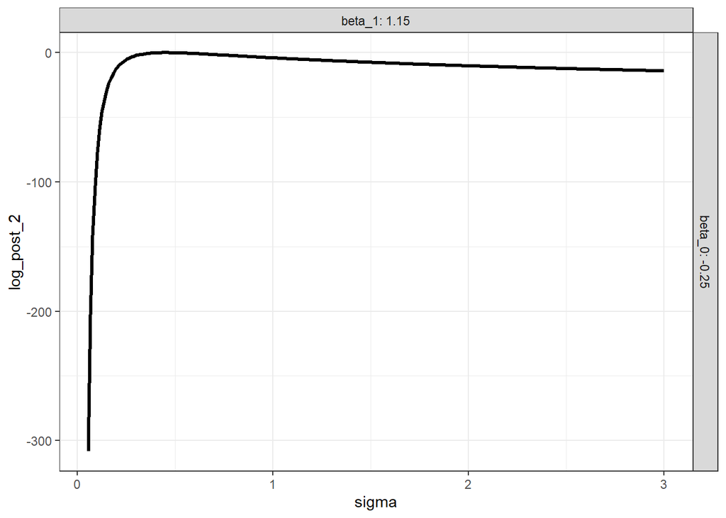

```r
simple_grid %>%
  mutate(log_post = log_post_simple_grid) %>%
  mutate(log_post_2 = log_post - max(log_post)) %>%
  ggplot(mapping = aes(x = sigma, y = log_post_2)) +
  geom_line(size = 1.15) +
  facet_grid(beta_0 ~ beta_1, labeller = "label_both") +
  theme_bw()
```

There seems to be a single unique mode around `sigma = 0.5`. Let’s zoom in using `coord_cartesian()` in our ggplot figure to get a better look at it. As we can see below, the mode is between 0.4 and 0.5. However, the curvature or steepness of the curve is very different to the left of the mode compared to the right of the mode. The steeper curve represents that the lower noise values are less probable compared with the noise values greater than 0.5.

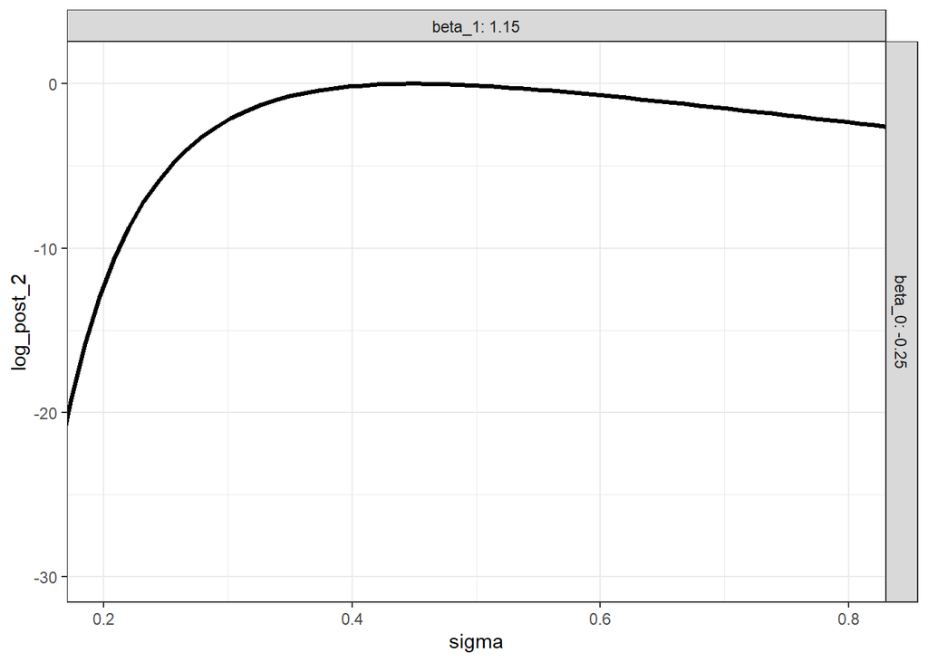

```r
simple_grid %>%
  mutate(log_post = log_post_simple_grid) %>%
  mutate(log_post_2 = log_post - max(log_post)) %>%
  ggplot(mapping = aes(x = sigma, y = log_post_2)) +
  geom_line(size = 1.15) +
  coord_cartesian(xlim = c(0.2, 0.8),
                  ylim = c(-30, 1)) +
  facet_grid(beta_0 ~ beta_1, labeller = "label_both") +
  theme_bw()
```

Let’s now see how the log-posterior with respect to $\sigma$ changes as we change the $\beta$ coefficients. After all, in a real problem we will not know the true coefficient values! The code chunk below uses `expand.grid()` to create a new set of combinations of the three values. Four specific values of the intercept and four specific values of the slope are used. The noise vector is set to be between 0.08 and 0.8, so that we can focus on behavior around the mode. A glimpse of the grid is printed to the screen, as well as all of the combinations of the intercept and slope.

```r
big_grid <- expand.grid(beta_0 = c(-0.75, -0.5, -0.25, 0),
                        beta_1 = c(0, 0.5, 1, 1.5),
                        sigma = seq(0.08, 0.8, length.out = 251),
                        KEEP.OUT.ATTRS = FALSE,
                        stringsAsFactors = FALSE) %>%
  as.data.frame() %>% tbl_df()

big_grid %>% glimpse()
```

```
## Observations: 4,016
## Variables: 3
## $ beta_0 <dbl> -0.75, -0.50, -0.25, 0.00, -0.75, -0.50, -0.25, 0.00, -...
## $ beta_1 <dbl> 0.0, 0.0, 0.0, 0.0, 0.5, 0.5, 0.5, 0.5, 1.0, 1.0, 1.0, ...
## $ sigma  <dbl> 0.08000, 0.08000, 0.08000, 0.08000, 0.08000, 0.08000, 0...
```

```r
big_grid %>% count(beta_0, beta_1)
```

```
## # A tibble: 16 x 3
##    beta_0 beta_1     n
##     <dbl>  <dbl> <int>
##  1  -0.75    0     251
##  2  -0.75    0.5   251
##  3  -0.75    1     251
##  4  -0.75    1.5   251
##  5  -0.5     0     251
##  6  -0.5     0.5   251
##  7  -0.5     1     251
##  8  -0.5     1.5   251
##  9  -0.25    0     251
## 10  -0.25    0.5   251
## 11  -0.25    1     251
## 12  -0.25    1.5   251
## 13   0       0     251
## 14   0       0.5   251
## 15   0       1     251
## 16   0       1.5   251
```

The log-posterior is calculated over the bigger grid using the same style of call to the `purrr::pmap_dbl()` function.

```r
log_post_big_grid <- purrr::pmap_dbl(list(big_grid$beta_0,
                                          big_grid$beta_1,
                                          big_grid$sigma),
                                     eval_logpost,
                                     logpost_func = my_logpost_lm_a,
                                     my_info = train_info)
```

Let’s now visualize the log-posterior. Separate facets are used for each combination of intercept and slope. Note that by default the `facet_grid()` function will order the lowest values of the vertical subplots starting at the top of the figure. Notice how in the column of subplots corresponding to no trend with the input (slope equals 0) the lowest values of the noise are completely ruled out. This has to do with the fact that if there is no trend, the variation in the observations can only be explained by noise. Thus, low values of noise would be considered no very likely.

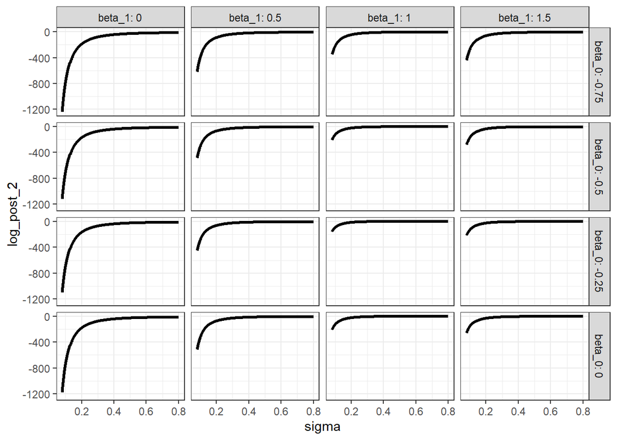

```r
big_grid %>%
  mutate(log_post = log_post_big_grid) %>%
  mutate(log_post_2 = log_post - max(log_post)) %>%
  ggplot(mapping = aes(x = sigma, y = log_post_2)) +
  geom_line(size = 1.15) +
  facet_grid(beta_0 ~ beta_1, labeller = "label_both") +
  theme_bw()
```

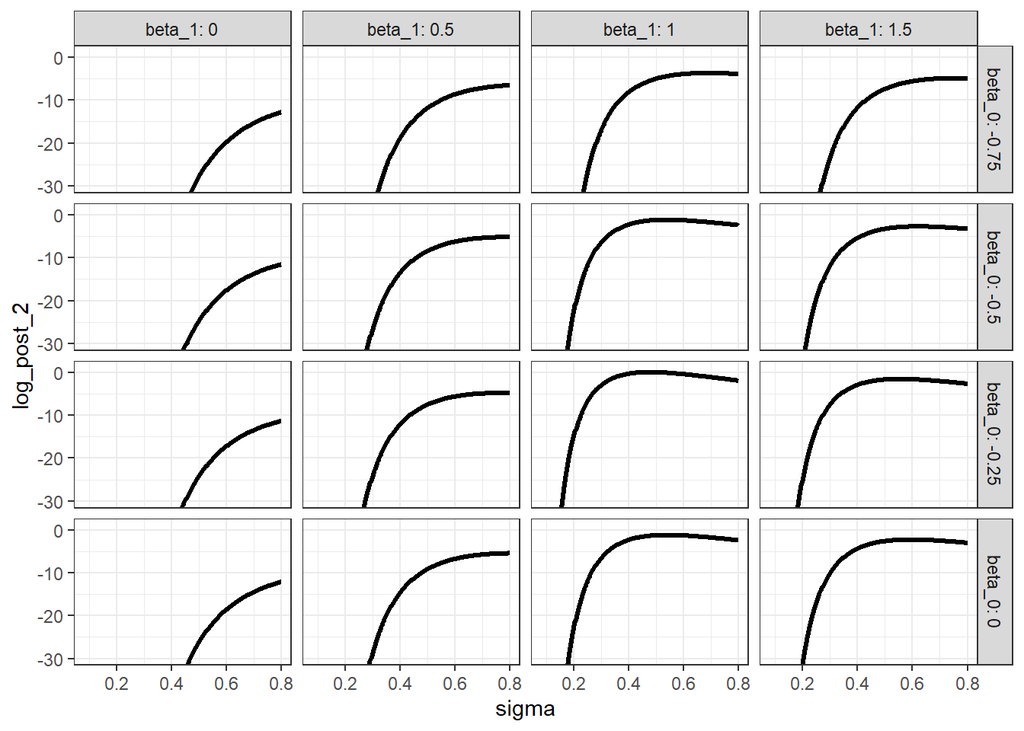

```r
big_grid %>%
  mutate(log_post = log_post_big_grid) %>%
  mutate(log_post_2 = log_post - max(log_post)) %>%
  ggplot(mapping = aes(x = sigma, y = log_post_2)) +
  geom_line(size = 1.15) +
  coord_cartesian(ylim = c(-30, 1)) +
  facet_grid(beta_0 ~ beta_1, labeller = "label_both") +
  theme_bw()
```

### Transformed variables

We could continue attempting to make visualizations to which describe the joint posterior density between $\beta_0$, $\beta_1$, and $\sigma$. However, it would be a little difficult to properly represent the complete joint structure and capture the uncertainty between all 3 variables, in high resolution. Instead, we will use the Laplace Approximation to identify the posterior mode and approximate the covariance and thus the uncertainty of all 3 variables. As discussed in lecture, applying the Laplace Approximation to $\sigma$ may result in the natural lower bound of $\sigma$ not being respected by the approximate MVN distribution. Further, we are using a uniform prior on $\sigma$. The imposed lower and upper bounds on $\sigma$ may not be respected by the approximate MVN distribution. To overcome these limitations we will apply the logit transformation and perform the Laplace Approximation on $\beta_0$, $\beta_1$, and the transformed unbounded variable $\varphi$.

We need to account for the change-of-variables transformation in our log-posterior function. To do that, we must calculate the log of the absolute value of the derivative of the inverse link function. The link function is a logit function, which is the same link used in the “weight example” from earlier in the course. In order to apply the logit, we must first normalized the noise to be between 0 and 1, based on its prior lower, $l$, and upper, $u$, uniform bounds:

$$\varphi = g\left(\sigma\right) = \mathrm{logit} \left( \frac{\sigma - l}{u - l} \right)$$

The inverse link function is then:

$$\sigma = g^{-1} \left(\varphi\right) = l + \left(u - l\right) \mathrm{logit}^{-1} \left(\varphi\right)$$

The absolute value of the derivative of the inverse link function is:

$$\frac{d}{d\varphi} \left(g^{-1} \left( \varphi \right) \right) = \left(u - l\right) \mathrm{logit}^{-1}\left(\varphi\right) \left( 1 - \mathrm{logit}^{-1}\left(\varphi\right)\right)$$

After some algebra, the log of the absolute value of the derivative can be written to be:

$$\log \left[ \frac{d}{d\varphi} \left(g^{-1} \left( \varphi \right) \right) \right] = \log\left[u - l\right] + \varphi - 2\log\left[\exp\left(\varphi\right) + 1 \right]$$

Using these definitions, we can modify our log-posterior function and define a new function `my_logpost_lm()` which is in terms of the $\beta$ coefficients and the transformed $\varphi$ variable. As shown in the code chunk below, a majority of the code is the same to the original `my_logpost_lm_a()` function. The differences are we must back-transform from $\varphi$ to $\sigma$ and we must account for the log of the derivative adjustment.

```r
my_logpost_lm <- function(unknowns, my_info)
{
  # extract the variables
  beta0 <- unknowns[1]
  beta1 <- unknowns[2]
  lik_varphi <- unknowns[3]

  # backtransform from varphi to sigma
  lik_sigma <- my_info$sigma_lwr +
    (my_info$sigma_upr - my_info$sigma_lwr) * boot::inv.logit(lik_varphi)

  # calculate the mean trend
  lik_mu <- beta0 + beta1 * my_info$xobs

  # calculate the log-likelihood
  log_lik <- sum(dnorm(x = my_info$yobs,
                       mean = lik_mu,
                       sd = lik_sigma,
                       log = TRUE))

  # calculate the log-prior on the coefficients
  log_prior_beta <- sum(dnorm(x = c(beta0, beta1),
                              mean = my_info$mu_beta,
                              sd = my_info$tau_beta,
                              log = TRUE))

  # calculate the log-prior on the noise
  log_prior_sigma <- dunif(x = lik_sigma,
                           min = my_info$sigma_lwr,
                           max = my_info$sigma_upr,
                           log = TRUE)

  # account for the derivative adjustment
  log_deriv_adjust <- log(my_info$sigma_upr - my_info$sigma_lwr) +
    lik_varphi - 2*log(exp(lik_varphi) + 1)

  # sum together
  log_lik + log_prior_beta + log_prior_sigma + log_deriv_adjust
}
```

Let’s test out that the function works. This time, we can pass in zeros for all unknown parameters, as well as negative numbers!

```r
my_logpost_lm(rep(0, 3), train_info)
```

```
## [1] -24.71356
```

```r
my_logpost_lm(rep(-1.5, 3), train_info)
```

```
## [1] -57.61876
```

Before executing the Laplace Approximation, let’s visualize the log-posterior over the a grid of candidate values again. This time the grid must be defined in terms of $\varphi$ instead of $\sigma$. Let’s adapt the procedure we used to create `big_grid`, but this time we will transform the bounds on $\sigma$ to $\varphi$ space.

```r
big_grid_phi <- expand.grid(beta_0 = c(-0.75, -0.5, -0.25, 0),
                            beta_1 = c(0, 0.5, 1, 1.5),
                            varphi = seq(boot::logit((0.08 - 0.05)/(5 - 0.05)),
                                         boot::logit((0.8 - 0.05)/(5 - 0.05)),
                                         length.out = 251),
                            KEEP.OUT.ATTRS = FALSE,
                            stringsAsFactors = FALSE) %>%
  as.data.frame() %>% tbl_df()
```

Let’s calculate the log-posterior on the unbounded variables over the grid.

```r
log_post_big_grid_phi <- purrr::pmap_dbl(list(big_grid_phi$beta_0,
                                              big_grid_phi$beta_1,
                                              big_grid_phi$varphi),
                                         eval_logpost,
                                         logpost_func = my_logpost_lm,
                                         my_info = train_info)
```

And now let’s visualize the log-posterior with respect to $\varphi$. We can see the curves are more “parabolic-like” which should be a little easier to work with for our Laplace Approximation.

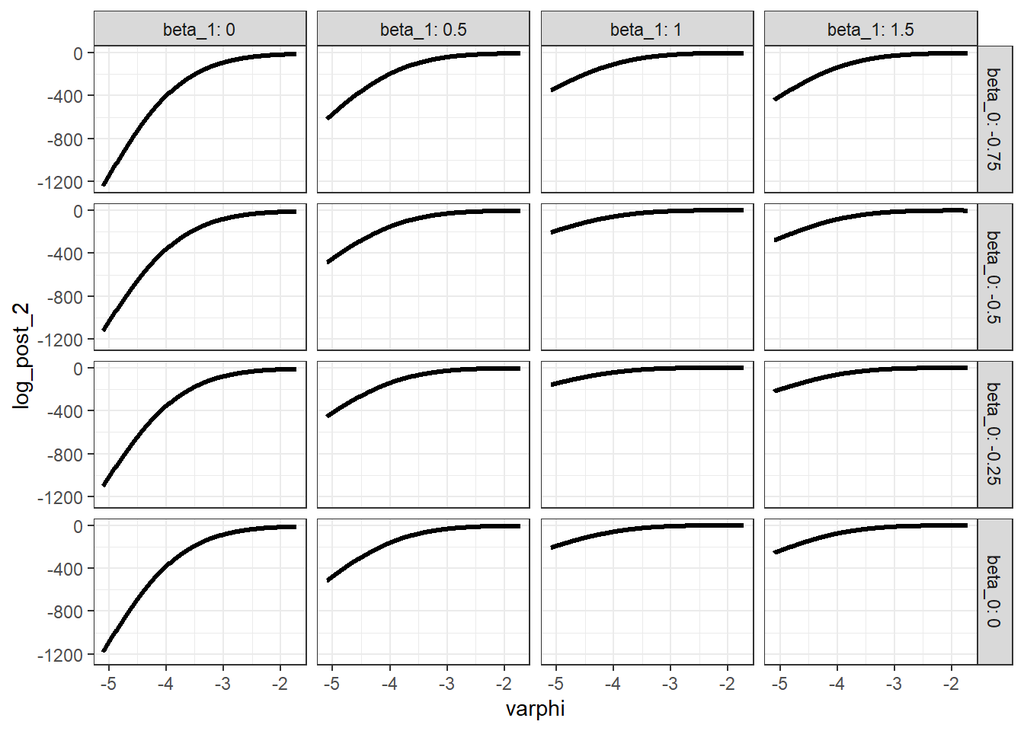

```r
big_grid_phi %>%
  mutate(log_post = log_post_big_grid_phi) %>%
  mutate(log_post_2 = log_post - max(log_post)) %>%
  ggplot(mapping = aes(x = varphi, y = log_post_2)) +
  geom_line(size = 1.15) +
  facet_grid(beta_0 ~ beta_1, labeller = "label_both") +
  theme_bw()
```

Let’s zoom in to just double check that is indeed the case.

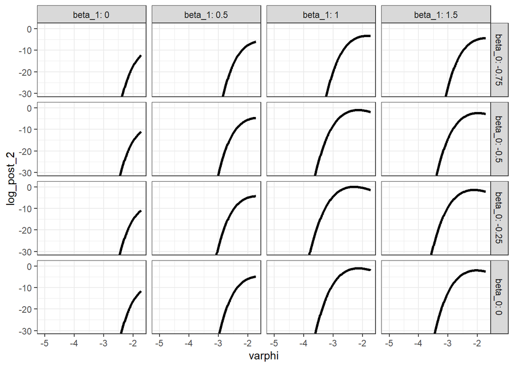

```r
big_grid_phi %>%
  mutate(log_post = log_post_big_grid_phi) %>%
  mutate(log_post_2 = log_post - max(log_post)) %>%
  ggplot(mapping = aes(x = varphi, y = log_post_2)) +
  geom_line(size = 1.15) +
  coord_cartesian(ylim = c(-30, 1)) +
  facet_grid(beta_0 ~ beta_1, labeller = "label_both") +
  theme_bw()
```

## Laplace Approximation

With the log-posterior function defined, let’s create the `my_laplace()` function which manages all steps of the Laplace Approximation. The first step is to find the posterior mode via optimization. The second step uses the Hessian matrix evaluated at the posterior mode to approximate the posterior covariance matrix. The first argument to the `my_laplace()` function is a vector of initial guess values. We must make sure that the length of the initial guess is equal to the total number of unknowns in our model. The second argument is the log-posterior function we are using for the problem. The last argument is “everything else” that is required to evaluate the log-posterior. For our current case, “everything else” corresponds to the `train_info` list.

```r
my_laplace <- function(start_guess, logpost_func, ...)
{
  # code adapted from the `LearnBayes`` function `laplace()`
  fit <- optim(start_guess,
               logpost_func,
               gr = NULL,
               ...,
               method = "BFGS",
               hessian = TRUE,
               control = list(fnscale = -1, maxit = 1001))

  mode <- fit$par
  h <- -solve(fit$hessian)
  p <- length(mode)
  int <- p/2 * log(2 * pi) + 0.5 * log(det(h)) + logpost_func(mode, ...)
  list(mode = mode,
       var_matrix = h,
       log_evidence = int,
       converge = ifelse(fit$convergence == 0,
                         "YES",
                         "NO"),
       iter_counts = fit$counts[1])
}
```

Before we execute the Laplace Approximation, should we be worried about the initial starting guess impacting our final result? Let’s check by trying out two different initial guesses. The first uses zeros for all parameters, and the second uses random initial guess.

```r
laplace_result_01 <- my_laplace(rep(0, 3), my_logpost_lm, train_info)
```

```r
### set the seed for reproducibility
set.seed(71231)
second_guess <- rnorm(3)
laplace_result_02 <- my_laplace(second_guess, my_logpost_lm, train_info)
```

Let’s now compare the identified posterior modes between the two different starting guesses. As shown in the print out below, although they are not exactly the same, for all practical purposes they are similar.

```r
laplace_result_01$mode
```

```
## [1] -0.2409759  1.1593594 -2.3671233
```

```r
laplace_result_02$mode
```

```
## [1] -0.2409349  1.1593567 -2.3671172
```

Let’s now compare the posterior covariance matrices. Again, they are not exactly the same, but for all practical purposes they are identical.

```r
laplace_result_01$var_matrix
```

```
##              [,1]          [,2]          [,3]
## [1,] 2.253001e-02  0.0016899589  7.450839e-05
## [2,] 1.689959e-03  0.0246608556 -6.051526e-04
## [3,] 7.450839e-05 -0.0006051526  8.205382e-02
```

```r
laplace_result_02$var_matrix
```

```
##              [,1]          [,2]          [,3]
## [1,] 2.253024e-02  0.0016899349  7.999425e-05
## [2,] 1.689935e-03  0.0246611075 -6.055168e-04
## [3,] 7.999425e-05 -0.0006055168  8.205466e-02
```

Lastly, let’s make sure both cases converged. As shown below, both cases did in fact converge!

```r
purrr::map_chr(list(laplace_result_01, laplace_result_02), "converge")
```

```
## [1] "YES" "YES"
```

### Posterior analysis

#### Intercept and slope

Since we feel comfortable that we did in fact find the posterior mode, let’s examine the results a little more closely. The posterior mode, is the vector of most probable values. So we would want to compare the posterior mode of the intercept to the true intercept and compare the posterior mode of the slope to the true slope. This way we can check if our learning algorithm was able to succesfully recover the parameter values that generated the data. Since the results are basically the same for either starting guess, we will use just the results from the first case. The code chunk below prints out the posterior mode associated with the $\beta$ parameters with a comparison to the true parameter values.

```r
tibble::tibble(
  param_name = c("Intercept", "Slope"),
  post_mode = laplace_result_01$mode[1:2],
  true_value = c(beta_0_true, beta_1_true)
)
```

```
## # A tibble: 2 x 3
##   param_name post_mode true_value
##   <chr>          <dbl>      <dbl>
## 1 Intercept     -0.241      -0.25
## 2 Slope          1.16        1.15
```

I would say the posterior modes are quite accurate. However, we cannot just look at this point estimate. We need to consider the uncertainty in our estimate. In a Bayesian framework, the uncertainty is easily evaluated because we have the posterior distribution. With the present use of the Laplace Approximation, both the intercept, $\beta_0$, and the slope, $\beta_1$, have posterior (marginal) Gaussian distributions. The posterior standard deviation on the parameters is just the square root of the main diagonal of the posterior covariance matrix. The code chunk below, expands upon the previous display by including the posterior standard deviation on both coefficients.

```r
tibble::tibble(
  param_name = c("Intercept", "Slope"),
  post_mode = laplace_result_01$mode[1:2],
  post_sd = sqrt(diag(laplace_result_01$var_matrix))[1:2],
  true_value = c(beta_0_true, beta_1_true)
)
```

```
## # A tibble: 2 x 4
##   param_name post_mode post_sd true_value
##   <chr>          <dbl>   <dbl>      <dbl>
## 1 Intercept     -0.241   0.150      -0.25
## 2 Slope          1.16    0.157       1.15
```

We can summarize the coefficients even further by considering their middle 95% uncertainty interval around the mean. In classic, frequentist, statistics if zero is not contained within the 95% confidence interval, the input associated with that parameter is considered statistically significant. Let’s calculate the approximate middle 95% uncertainty intervals on the intercept and slope by simply adding and subtracting two posterior standard deviations from the posterior mean. Based on the results shown below, would you feel the input is important? Does the response definitely increase as the input increases?

```r
tibble::tibble(
  param_name = c("Intercept", "Slope"),
  post_mode = laplace_result_01$mode[1:2],
  post_sd = sqrt(diag(laplace_result_01$var_matrix))[1:2],
  true_value = c(beta_0_true, beta_1_true)
) %>%
  mutate(post_lwr = post_mode - 2*post_sd,
         post_upr = post_mode + 2*post_sd)
```

```
## # A tibble: 2 x 6
##   param_name post_mode post_sd true_value post_lwr post_upr
##   <chr>          <dbl>   <dbl>      <dbl>    <dbl>    <dbl>
## 1 Intercept     -0.241   0.150      -0.25   -0.541   0.0592
## 2 Slope          1.16    0.157       1.15    0.845   1.47
```

So far, we’ve looked at the marginal behavior of the coefficients. Let’s now consider how they behave together by examining the posterior correlation between the intercept and slope. The Laplace Approximation produces the covariance matrix between the unknowns, so we have to perform an action to convert from covariance to correlation. A quick way to do so in `R` is with the `cov2cor()` function, which reads in a covariance matrix and outputs the correspdonding correlation matrix. The code chunk below produces the posterior correlation matrix between the intercept and slope. As shown below, the posterior correlation between the intercept and slope is quite low.

```r
cov2cor(laplace_result_01$var_matrix[1:2, 1:2])
```

```
##            [,1]       [,2]
## [1,] 1.00000000 0.07169542
## [2,] 0.07169542 1.00000000
```

#### Noise

The posterior analysis of the intercept and slope are rather straight forward. We can use the Laplace Approximation result directly to answer most questions we might have. However, we did not find the posterior in terms of $\sigma$. So if we want analyze the behavior of the unknown noise, we are going to have back-transform from the $\varphi$ space to the $\sigma$ space. Rather than working through the change-of-variables in reverse, I prefer to use random samples to take care of the back-transformation for us. So we will use the fact that the Laplace Approximation result is a MVN distribution to easily generate thousands of random samples. We will calculate $\sigma$ directly from those samples on $\varphi$. In doing so, we will fully respect any correlation structure that might exist between the noise and the $\beta$ parameters.

The code chunk below uses the `MASS::mvrnorm()` function to generate $10^4$ random samples from the approximate joint posterior on $\beta_0$, $\beta_1$, and $\varphi$. After some data type conversions and book keeping changes, the result is piped into a `mutate()` call where $\sigma$ is calculated based on $\varphi$.

```r
set.seed(11231)
post_samples <- MASS::mvrnorm(n = 1e4,
                              mu = laplace_result_01$mode,
                              Sigma = laplace_result_01$var_matrix) %>%
  as.data.frame() %>% tbl_df() %>%
  purrr::set_names(c("beta_0", "beta_1", "varphi")) %>%
  mutate(sigma = train_info$sigma_lwr +
           (train_info$sigma_upr - train_info$sigma_lwr)*boot::inv.logit(varphi))
```

Print out the summary on the posterior samples to show there are 4 variables and their respective central tendancies and ranges. From the `summary()` call below, we can see that the posterior mean on $\sigma$ is very close to the true $\sigma$ value of 0.5.

```r
post_samples %>% summary()
```

```
##      beta_0            beta_1           varphi           sigma
##  Min.   :-0.7848   Min.   :0.6089   Min.   :-3.372   Min.   :0.2142
##  1st Qu.:-0.3447   1st Qu.:1.0542   1st Qu.:-2.555   1st Qu.:0.4069
##  Median :-0.2444   Median :1.1609   Median :-2.356   Median :0.4788
##  Mean   :-0.2438   Mean   :1.1599   Mean   :-2.360   Mean   :0.4905
##  3rd Qu.:-0.1433   3rd Qu.:1.2662   3rd Qu.:-2.163   3rd Qu.:0.5606
##  Max.   : 0.3209   Max.   :1.7283   Max.   :-1.293   Max.   :1.1163
```

We can look at the posterior histograms to help us visualize the shape of the posterior distributions. You should be able to guess the shape of the intercept, slope, and $\varphi$ posterior distributions before generating the figure. Rather than making each histogram separately, the code chunk below first reshapes the `post_samples` data set into a long-format to enable creating separating facets with `ggplot2` directly.

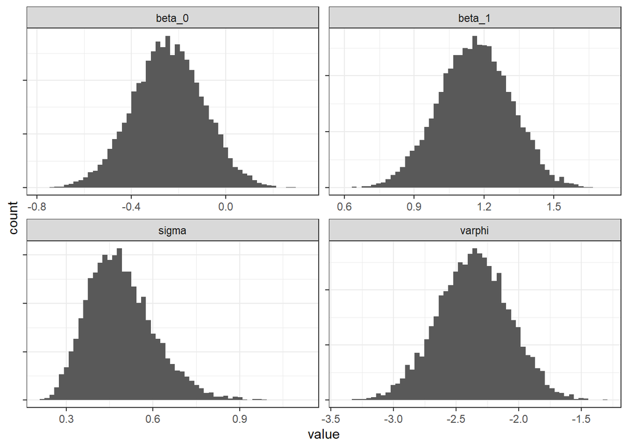

```r
post_samples %>%
  tibble::rowid_to_column("post_id") %>%
  tidyr::gather(key = "param_name", value = "value", -post_id) %>%
  ggplot(mapping = aes(x = value)) +
  geom_histogram(bins = 55) +
  facet_wrap(~param_name, scales = "free") +
  theme_bw() +
  theme(axis.text.y = element_blank())
```

Even though the posterior mean on $\sigma$ is very close to the true value, there still seems to be some rather high values in the posterior samples. Let’s consider the probability that $\sigma$ is greater than 0.7. To calculate that probability we just have to count the number of times `sigma` exceeds 0.7 and divide by the total number trials. A simple way to do that is with the `mean()` function. As shown below, there’s only about a 5% chance that the noise is greater than 0.7.

```r
mean(post_samples$sigma > 0.7)
```

```
## [1] 0.052
```

Lastly we can consider the relationship between all 3 of the original parameters, $\beta_0$, $\beta_1$, and $\sigma$. A quick way to do that is to examine the posterior correlation matrix. Rather than printing it out let’s use `corrplot()` to display a graphic. As shown below, the $\beta$ coefficients are not correlated to the noise.

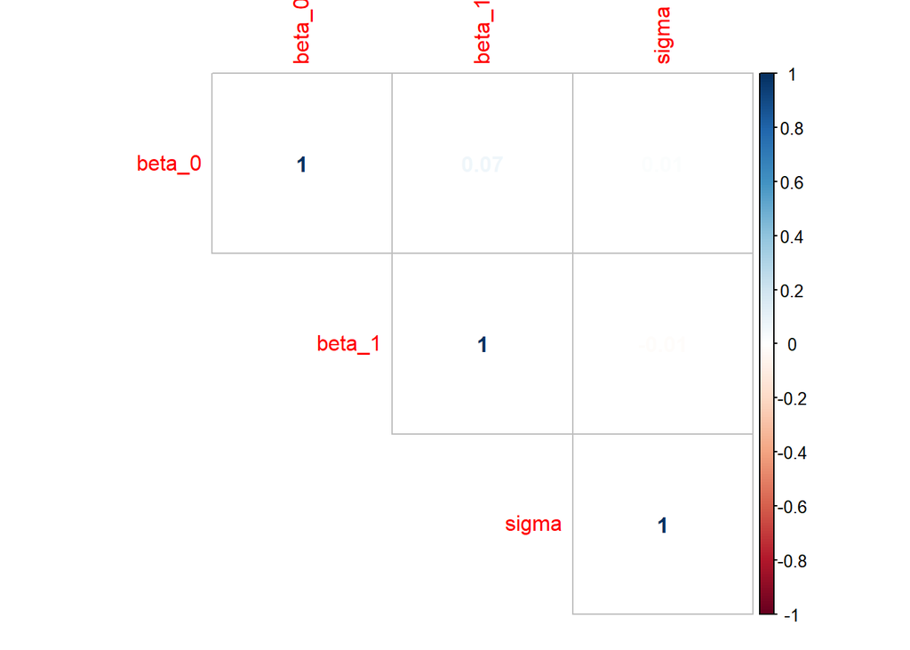

```r
post_samples %>%
  select(-varphi) %>%
  as.data.frame() %>%
  cor() %>%
  corrplot::corrplot(type = "upper", method = "number")
```